# Blog

# Load data

Load the package *rerddap*

```r
library("rerddap")
```

Check the list of available servers.

For the example, we are interested in the Pacific Ocean, therefore I would use NOAA.

```r
servers()
```

I want to download sea surface temperature (SST) data, therefore I will use *erdMH1sstdmday*

```r
sstInfo <- info('erdMH1sstdmday')
```

To check the specifications use *browse*

```r
browse('erdMH1sstdmday')
```

It takes some time to download.

```r
SST03.2017<-griddap(sstInfo, latitude = c(ylim1, ylim2), longitude = c(xlim1, xlim2), time = c(time1,time2), fields = 'sst')
```

```
## info() output passed to x; setting base url to: https://upwell.pfeg.noaa.gov/erddap
```

To use ggplot, the format in dataframe works better.

```r
SST03.2017dt<-SST03.2017$data
```

Clear NaNs

```r
library(tidyverse)
```

```r
SST03.2017dt_clean<-SST03.2017dt %>%
  filter(sst!='NaN')
```

Create plot

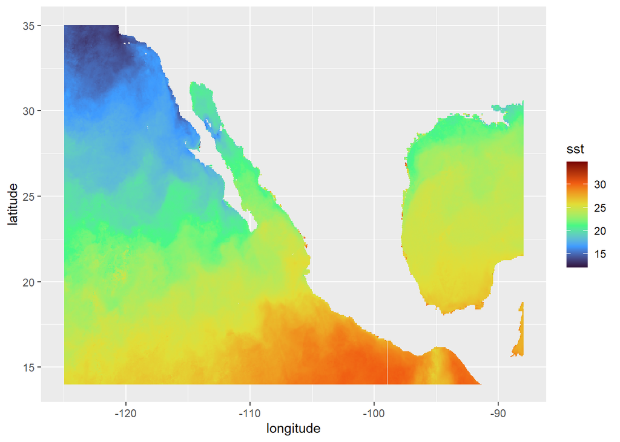

```r
ggplot(SST03.2017dt_clean) +
 geom_raster(aes(x=longitude, y=latitude, fill = sst))+
  scale_fill_viridis_c(option = "H")
```

# Add land for reference

Load the package *rworldmap* this includes shapefiles of countries

```r
library(rworldmap)
```

The function *getMap()* loads the map in your environment

```r
worldMap <- getMap()
```

Load the package tidyverse

Use the function *fortify* to be able to plot the map using ggplot

```r
world.points <- fortify(worldMap)
```

To plot using ggplot a data frame is recommended

```r
world.points$region <- world.points$id
world.df <- world.points[,c("long","lat","group", "region")]
```

Create plot using ggplot

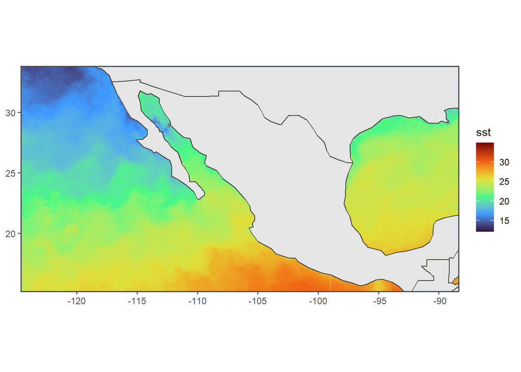

```r
ggplot(SST03.2017dt) +
  geom_raster(aes(x=longitude, y=latitude, fill = sst))+
  geom_polygon(data = world.df, aes(x = long, y = lat, group = group), colour = '#403d39', fill = "#e5e5e5") +
  theme(
    axis.title = element_blank(),
    panel.border = element_rect(colour = "#495057", fill=NA, size=1),
    panel.grid = element_blank(),
    panel.spacing = unit(0, "lines"),
    plot.background = element_blank())+
    coord_sf(xlim = c(xlim1+2,xlim2-2),
             ylim = c(ylim1+2,ylim2-2))+
  scale_fill_viridis_c(option = "H")
```

# ~~~~~~~~~~~~~

# 3. March

# Double axis

# Intro

This post is to create a plot with environmental variables, in one axis the sea surface temperature and in the other axis the chlorophyll-a concentration.

1. Download data from the server
2. Calculate average values
3. Create a secondary-axis plot with the values

# Load data

Load the package **rerddap**

```r
library("rerddap")
```

**SST: sea surface temperature**

For obtaining data, download sea surface temperature (SST) from **erdMWsstd1day_LonPM180** (link here).

Another option is **erdMW1sstd1day** (link here).

To search other options [here](https://upwell.pfeg.noaa.gov/erddap/index.html).

```r
sstInfo <- info('erdMWsstd1day_LonPM180')
```

To subset the data select the coordinates of a smaller area.

```r
lonmin<--111
lonmax<--109
latmin<-23
latmax<-27
```

To download, provide the parameters such as the server, the coordinates and the time frame. It takes some time to download.

```r
SST03.2023<-griddap(sstInfo,
                    latitude= c(latmin, latmax), longitude = c(lonmin, lonmax),
                    time = c('2023-03-01T00:00:00Z','2023-03-30T00:00:00Z'),
                    fields = 'sst')
```

```
## info() output passed to x; setting base url to: https://upwell.pfeg.noaa.gov/erddap
```

```r
SST04.2023<-griddap(sstInfo,
                    latitude= c(latmin, latmax), longitude = c(lonmin, lonmax),
                    time = c('2023-04-01T00:00:00Z','2023-04-30T00:00:00Z'),
                    fields = 'sst')
```

```
## info() output passed to x; setting base url to: https://upwell.pfeg.noaa.gov/erddap
```

```r
SST05.2023<-griddap(sstInfo,
                    latitude= c(latmin, latmax), longitude = c(lonmin, lonmax),
                    time = c('2023-05-01T00:00:00Z','2023-05-30T00:00:00Z'),
                    fields = 'sst')
```

```
## info() output passed to x; setting base url to: https://upwell.pfeg.noaa.gov/erddap
```

```r
SST06.2023<-griddap(sstInfo,
                    latitude= c(latmin, latmax), longitude = c(lonmin, lonmax),
                    time = c('2023-06-01T00:00:00Z','2023-06-30T00:00:00Z'),
                    fields = 'sst')
```

```
## info() output passed to x; setting base url to: https://upwell.pfeg.noaa.gov/erddap
```

```r
SST07.2023<-griddap(sstInfo,
                    latitude= c(latmin, latmax), longitude = c(lonmin, lonmax),
                    time = c('2023-07-01T00:00:00Z','2023-07-30T00:00:00Z'),
                    fields = 'sst')
```

```
## info() output passed to x; setting base url to: https://upwell.pfeg.noaa.gov/erddap
```

```r
SST08.2023<-griddap(sstInfo,
                    latitude= c(latmin, latmax), longitude = c(lonmin, lonmax),
                    time = c('2023-08-01T00:00:00Z','2023-08-30T00:00:00Z'),
                    fields = 'sst')
```

```
## info() output passed to x; setting base url to: https://upwell.pfeg.noaa.gov/erddap
```

```r
SST09.2023<-griddap(sstInfo,
                    latitude= c(latmin, latmax), longitude = c(lonmin, lonmax),
                    time = c('2023-09-01T00:00:00Z','2023-09-30T00:00:00Z'),
                    fields = 'sst')
```

```
## info() output passed to x; setting base url to: https://upwell.pfeg.noaa.gov/erddap
```

```r
SST10.2023<-griddap(sstInfo,
                    latitude= c(latmin, latmax), longitude = c(lonmin, lonmax),
                    time = c('2023-10-01T00:00:00Z','2023-10-30T00:00:00Z'),
                    fields = 'sst')
```

```
## info() output passed to x; setting base url to: https://upwell.pfeg.noaa.gov/erddap
```

```r
SST11.2023<-griddap(sstInfo,
                    latitude= c(latmin, latmax), longitude = c(lonmin, lonmax),
                    time = c('2023-11-01T00:00:00Z','2023-11-30T00:00:00Z'),
                    fields = 'sst')
```

```
## info() output passed to x; setting base url to: https://upwell.pfeg.noaa.gov/erddap
```

```r
SST12.2023<-griddap(sstInfo,
                    latitude= c(latmin, latmax), longitude = c(lonmin, lonmax),
                    time = c('2023-12-01T00:00:00Z','2023-12-30T00:00:00Z'),
                    fields = 'sst')
```

```
## info() output passed to x; setting base url to: https://upwell.pfeg.noaa.gov/erddap
```

**CHL: chlorophyll-a concentration**

To download chlorophyll concentration (CHL) data, connect to **erdMWchlamday_LonPM180** (here the [link](https://upwell.pfeg.noaa.gov/erddap/griddap/erdMWchlamday_LonPM180.html).

Another option is **erdMW1CHLd1day** (here the [link](https://upwell.pfeg.noaa.gov/erddap/griddap/erdMWcflh3day.graph))

```r
CHLInfo <- info('erdMWchlamday_LonPM180')
```

To subset the data select the coordinates of a smaller area.

To download, provide the parameters such as the server, the coordinates and the time frame. It takes some time to download.

```r
CHL03.2023<-griddap(CHLInfo,
                    latitude = c(latmin, latmax), longitude = c(lonmin, lonmax),
                    time = c('2023-03-01T00:00:00Z','2023-03-30T00:00:00Z'),
                    fields = 'chlorophyll')
```

```
## info() output passed to x; setting base url to: https://upwell.pfeg.noaa.gov/erddap
```

```r
CHL04.2023<-griddap(CHLInfo,
                    latitude = c(latmin, latmax), longitude = c(lonmin, lonmax),
                    time = c('2023-04-01T00:00:00Z','2023-04-30T00:00:00Z'),
                    fields = 'chlorophyll')
```

```
## info() output passed to x; setting base url to: https://upwell.pfeg.noaa.gov/erddap
```

```r
CHL05.2023<-griddap(CHLInfo,
                    latitude = c(latmin, latmax), longitude = c(lonmin, lonmax),
                    time = c('2023-05-01T00:00:00Z','2023-05-30T00:00:00Z'),
                    fields = 'chlorophyll')
```

```
## info() output passed to x; setting base url to: https://upwell.pfeg.noaa.gov/erddap
```

```r
CHL06.2023<-griddap(CHLInfo,
                    latitude = c(latmin, latmax), longitude = c(lonmin, lonmax),
                    time = c('2023-06-01T00:00:00Z','2023-06-30T00:00:00Z'),
                    fields = 'chlorophyll')
```

```
## info() output passed to x; setting base url to: https://upwell.pfeg.noaa.gov/erddap
```

```r
CHL07.2023<-griddap(CHLInfo,
                    latitude = c(latmin, latmax), longitude = c(lonmin, lonmax),
                    time = c('2023-07-01T00:00:00Z','2023-07-30T00:00:00Z'),
                    fields = 'chlorophyll')
```

```
## info() output passed to x; setting base url to: https://upwell.pfeg.noaa.gov/erddap
```

```r
CHL08.2023<-griddap(CHLInfo,
                    latitude = c(latmin, latmax), longitude = c(lonmin, lonmax),
                    time = c('2023-08-01T00:00:00Z','2023-08-30T00:00:00Z'),
                    fields = 'chlorophyll')
```

```
## info() output passed to x; setting base url to: https://upwell.pfeg.noaa.gov/erddap
```

```r
CHL09.2023<-griddap(CHLInfo,
                    latitude = c(latmin, latmax), longitude = c(lonmin, lonmax),
                    time = c('2023-09-01T00:00:00Z','2023-09-30T00:00:00Z'),
                    fields ='chlorophyll')
```

```
## info() output passed to x; setting base url to: https://upwell.pfeg.noaa.gov/erddap
```

```r
CHL10.2023<-griddap(CHLInfo,
                    latitude = c(latmin, latmax), longitude = c(lonmin, lonmax),
                    time = c('2023-10-01T00:00:00Z','2023-10-30T00:00:00Z'),
                    fields ='chlorophyll')
```

```
## info() output passed to x; setting base url to: https://upwell.pfeg.noaa.gov/erddap
```

```r
CHL11.2023<-griddap(CHLInfo,
                    latitude = c(latmin, latmax), longitude = c(lonmin, lonmax),
                    time = c('2023-11-01T00:00:00Z','2023-11-30T00:00:00Z'),
                    fields = 'chlorophyll')
```

```
## info() output passed to x; setting base url to: https://upwell.pfeg.noaa.gov/erddap
```

```r
CHL12.2023<-griddap(CHLInfo,
                    latitude = c(latmin, latmax), longitude = c(lonmin, lonmax),
                    time = c('2023-12-01T00:00:00Z','2023-12-30T00:00:00Z'),
                    fields = 'chlorophyll')
```

```
## info() output passed to x; setting base url to: https://upwell.pfeg.noaa.gov/erddap
```

# Average values

Load the package **tidyverse**.

```r
library(tidyverse)
```

**SST: sea surface temperature**

To calculate average values the best is to transform the data into a data frame.

```r
SST03.2023dt<-SST03.2023$data
SST04.2023dt<-SST04.2023$data
SST05.2023dt<-SST05.2023$data
SST06.2023dt<-SST06.2023$data
SST07.2023dt<-SST07.2023$data
SST08.2023dt<-SST08.2023$data
SST09.2023dt<-SST09.2023$data
SST10.2023dt<-SST10.2023$data
SST11.2023dt<-SST11.2023$data
SST12.2023dt<-SST12.2023$data
```

Functions from the package tidyverse can be used to calculate the **mean** values.  
The xaxis would be in numeric value for the plot.

```r
SST03.2023dt_clean<-SST03.2023dt %>%  drop_na(sst) %>%
  summarise(mean_sst=mean(sst),sd_sst=sd(sst))%>%
  mutate(month='03/2023', xaxis=1)

SST04.2023dt_clean<-SST04.2023dt %>%  drop_na(sst) %>%
  summarise(mean_sst=mean(sst),sd_sst=sd(sst))%>%
  mutate(month='04/2023', xaxis=2)

SST05.2023dt_clean<-SST05.2023dt %>%  drop_na(sst) %>%
  summarise(mean_sst=mean(sst),sd_sst=sd(sst))%>%
  mutate(month='05/2023', xaxis=3)

SST06.2023dt_clean<-SST06.2023dt %>%  drop_na(sst) %>%
  summarise(mean_sst=mean(sst),sd_sst=sd(sst))%>%
  mutate(month='06/2023', xaxis=4)

SST07.2023dt_clean<-SST07.2023dt %>%  drop_na(sst) %>%
  summarise(mean_sst=mean(sst),sd_sst=sd(sst))%>%
  mutate(month='07/2023', xaxis=5)

SST08.2023dt_clean<-SST08.2023dt %>%  drop_na(sst) %>%
  summarise(mean_sst=mean(sst),sd_sst=sd(sst))%>%
  mutate(month='08/2023', xaxis=6)

SST09.2023dt_clean<-SST09.2023dt %>%  drop_na(sst) %>%
  summarise(mean_sst=mean(sst),sd_sst=sd(sst))%>%
  mutate(month='09/2023', xaxis=7)

SST10.2023dt_clean<-SST10.2023dt %>%  drop_na(sst) %>%
  summarise(mean_sst=mean(sst),sd_sst=sd(sst))%>%
  mutate(month='10/2023', xaxis=8)

SST11.2023dt_clean<-SST11.2023dt %>%  drop_na(sst) %>%
  summarise(mean_sst=mean(sst),sd_sst=sd(sst))%>%
  mutate(month='11/2023', xaxis=9)

SST12.2023dt_clean<-SST12.2023dt %>%  drop_na(sst) %>%
  summarise(mean_sst=mean(sst),sd_sst=sd(sst))%>%
  mutate(month='12/2023', xaxis=10)
```

Now join into a single data frame.

```r
SST_months<-rbind(SST03.2023dt_clean,
      SST04.2023dt_clean,
      SST05.2023dt_clean,
      SST06.2023dt_clean,
      SST07.2023dt_clean,
      SST08.2023dt_clean,
      SST09.2023dt_clean,
      SST10.2023dt_clean,
      SST11.2023dt_clean,
      SST12.2023dt_clean
      )
```

**CHL: chlorophyll-a concentration**

The same procedure used with SST, would be used with CHL.

Convert to data frame.

```r
CHL03.2023dt<-CHL03.2023$data
CHL04.2023dt<-CHL04.2023$data
CHL05.2023dt<-CHL05.2023$data
CHL06.2023dt<-CHL06.2023$data
CHL07.2023dt<-CHL07.2023$data
CHL08.2023dt<-CHL08.2023$data
CHL09.2023dt<-CHL09.2023$data
CHL10.2023dt<-CHL10.2023$data
CHL11.2023dt<-CHL11.2023$data
CHL12.2023dt<-CHL12.2023$data
```

Calculate the mean values. Include the xaxis.

```r
CHL03.2023dt_clean<-CHL03.2023dt %>%  drop_na(chlorophyll) %>%
  summarise(mean_CHL=mean(chlorophyll),sd_CHL=sd(chlorophyll))%>%
  mutate(month='03/2023', xaxis=1)

CHL04.2023dt_clean<-CHL04.2023dt %>%  drop_na(chlorophyll) %>%
  summarise(mean_CHL=mean(chlorophyll),sd_CHL=sd(chlorophyll))%>%
  mutate(month='04/2023', xaxis=2)

CHL05.2023dt_clean<-CHL05.2023dt %>%  drop_na(chlorophyll) %>%
  summarise(mean_CHL=mean(chlorophyll),sd_CHL=sd(chlorophyll))%>%
  mutate(month='05/2023', xaxis=3)

CHL06.2023dt_clean<-CHL06.2023dt %>%  drop_na(chlorophyll) %>%
  summarise(mean_CHL=mean(chlorophyll),sd_CHL=sd(chlorophyll))%>%
  mutate(month='06/2023', xaxis=4)

CHL07.2023dt_clean<-CHL07.2023dt %>%  drop_na(chlorophyll) %>%
  summarise(mean_CHL=mean(chlorophyll),sd_CHL=sd(chlorophyll))%>%
  mutate(month='07/2023', xaxis=5)

CHL08.2023dt_clean<-CHL08.2023dt %>%  drop_na(chlorophyll) %>%
  summarise(mean_CHL=mean(chlorophyll),sd_CHL=sd(chlorophyll))%>%
  mutate(month='08/2023', xaxis=6)

CHL09.2023dt_clean<-CHL09.2023dt %>%  drop_na(chlorophyll) %>%
  summarise(mean_CHL=mean(chlorophyll),sd_CHL=sd(chlorophyll))%>%
  mutate(month='09/2023', xaxis=7)

CHL10.2023dt_clean<-CHL10.2023dt %>%  drop_na(chlorophyll) %>%
  summarise(mean_CHL=mean(chlorophyll),sd_CHL=sd(chlorophyll))%>%
  mutate(month='10/2023', xaxis=8)
CHL11.2023dt_clean<-CHL11.2023dt %>%  drop_na(chlorophyll) %>%
  summarise(mean_CHL=mean(chlorophyll),sd_CHL=sd(chlorophyll))%>%
  mutate(month='11/2023', xaxis=9)

CHL12.2023dt_clean<-CHL12.2023dt %>%  drop_na(chlorophyll) %>%
  summarise(mean_CHL=mean(chlorophyll),sd_CHL=sd(chlorophyll))%>%
  mutate(month='12/2023', xaxis=10)
```

Create a data frame with all the values.

```r
CHL_months<-rbind(CHL03.2023dt_clean,
      CHL04.2023dt_clean,
      CHL05.2023dt_clean,
      CHL06.2023dt_clean,
      CHL07.2023dt_clean,
      CHL08.2023dt_clean,
      CHL09.2023dt_clean,
      CHL10.2023dt_clean,
      CHL11.2023dt_clean,
      CHL12.2023dt_clean
      )
```

# Two-axis plot

**SST: sea surface temperature**

Create a plot using **geom_line** using functions from the package ggplot.

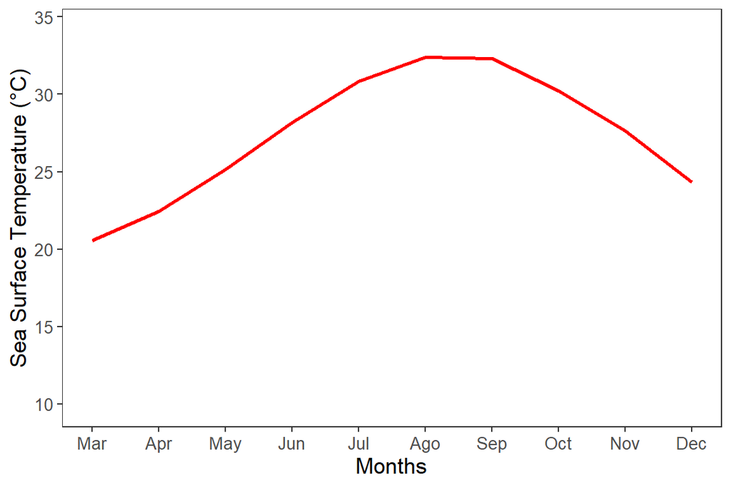

```r
plot_SST<-ggplot(SST_months) +
  geom_line(aes(x = xaxis, y = mean_sst),color='red', size=1)+
  scale_y_continuous(("Sea Surface Temperature (°C)"),limits=c(8.5,35.5),expand=c(0, 0))+
    scale_x_continuous("Months",breaks=c(1,2,3,4,5,6,7,8,9,10),labels=c('Mar','Apr','May','Jun','Jul','Ago','Sep','Oct','Nov','Dec'))+
  theme_bw()+#dejar lineas de las orillas
  theme(axis.title.x = element_text(size=13),
        axis.text.x = element_text(size=10),
        axis.title.y=element_text(size=13),
        axis.text.y=element_text(size=10),
        panel.grid.major = element_blank(),
        panel.grid.minor = element_blank(),
        panel.background = element_blank())+
  NULL
plot_SST
```

**CHL: chlorophyll-a concentration**

Create your second plot with functions from the package ggplot.

For this plot, as it would be on top of the other, the panel background, border, and plot background should be transparent.

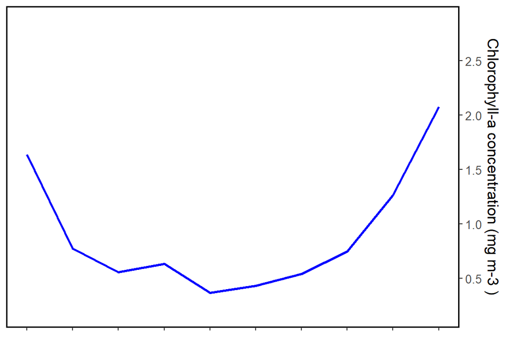

```r
plot_CHL<-ggplot(CHL_months) +
  geom_line(aes(x = xaxis, y = mean_CHL),color='blue', size=1) +
  scale_y_continuous(("Chlorophyll-a concentration (mg m-3 )"),limits=c(0.05,3.0),breaks=c(0.5,1,1.5,2,2.5),expand=c(0, 0),position = "right")+
  scale_x_continuous("Months",breaks=c(1,2,3,4,5,6,7,8,9,10),labels=c('Mar','Apr','May','Jun','Jul','Ago','Sep','Oct','Nov','Dec'))+
  theme(axis.title.x = element_blank(),
        axis.text.x = element_blank(),
        axis.title.y = element_text(size = 13, vjust=6),
        axis.text.y = element_text(size = 10),
        panel.grid.major = element_blank(),
        panel.grid.minor = element_blank(),
        panel.background = element_rect(fill='transparent'),
        panel.border = element_rect(colour = "black", fill='transparent', size=1),
        plot.background = element_rect(fill = 'transparent',colour = 'transparent',linewidth = 1))
plot_CHL
```

# Add legend

Using **annotate** the legend would be included inside the plot.

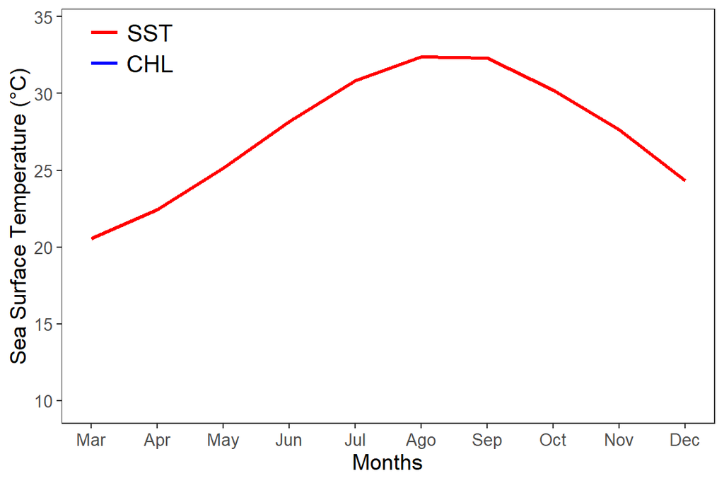

```r
plot_SST_wlegend<-plot_SST+
  annotate("text", x = c(1.9), y = c(34), label = c("SST") , color="black", size=5)+
  annotate("segment", x = 1.0, xend = 1.4, y = 34, yend = 34, colour = "red", size=1, alpha=1)+

  annotate("text", x = c(1.9), y = c(32), label = c("CHL") , color="black", size=5)+
  annotate("segment", x = 1.0, xend = 1.4, y = 32, yend = 32, colour = "blue", size=1, alpha=1)+
  NULL
plot_SST_wlegend
```

# Join graphs

Using functions from the package **patchwork** both plots would be merge into one.

```r
library(patchwork)
```

To further learn how to change the layout [click here](https://patchwork.data-imaginist.com/articles/guides/layout.html).

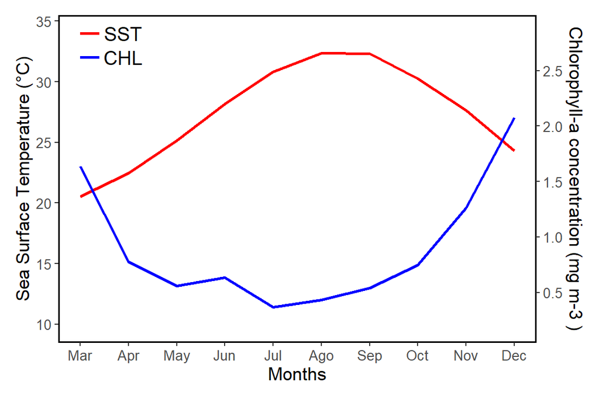

```r
plot_SST_wlegend + plot_CHL+
  plot_layout(design = c(area(t = 1, l = 1, b = 5, r = 4),
            area(t = 1, l = 1, b = 5, r = 4)))
```

# ~~~~~~~~~~~~~

# 4. April

# Buffer

In this blog, a buffer subsetting environmental data would be created and the average values within the buffer calculated.

# Download data

Load the package **rerddap**

```r
library("rerddap")
```

```r
SST_info <- info('erdMWsstd1day_LonPM180')
```

To subset the data select the coordinates of a smaller area.

```r
lonmin<--111
lonmax<--109
latmin<-23
latmax<-27
```

To download, provide the parameters such as the server, the coordinates and the time frame. It takes some time to download.

```r
SST_values<-griddap(SST_info,
                    latitude= c(latmin, latmax), longitude = c(lonmin, lonmax),
                    time = c('2023-03-01T00:00:00Z','2023-03-30T00:00:00Z'),
                    fields = 'sst')
```

```
## info() output passed to x; setting base url to: https://upwell.pfeg.noaa.gov/erddap
```

To access the data as data frame, extract the data.

```r
SST_df<-SST_values$data
```

Using functions from the package tidyverse, remove all NAs.

```r
library(tidyverse)
```

```r
SST_dfclean<-SST_df %>%
  filter(sst!='NaN')
```

# Map

Check data downloaded using ggplot.

```r
library(ggplot2)
```

Download data from land from the package **rworldmap**.

```r
library(rworldmap)
```

The function *getMap()* loads the map in your environment.

```r
world_map <- getMap()
```

To plot using ggplot a data frame is recommended. Use the function *fortify* to be able to get the data in a data frame format.

```r
world_points <- fortify(world_map)
world_points$region <- world_points$id
world_df <-world_points[,c("long","lat","group", "region")]
```

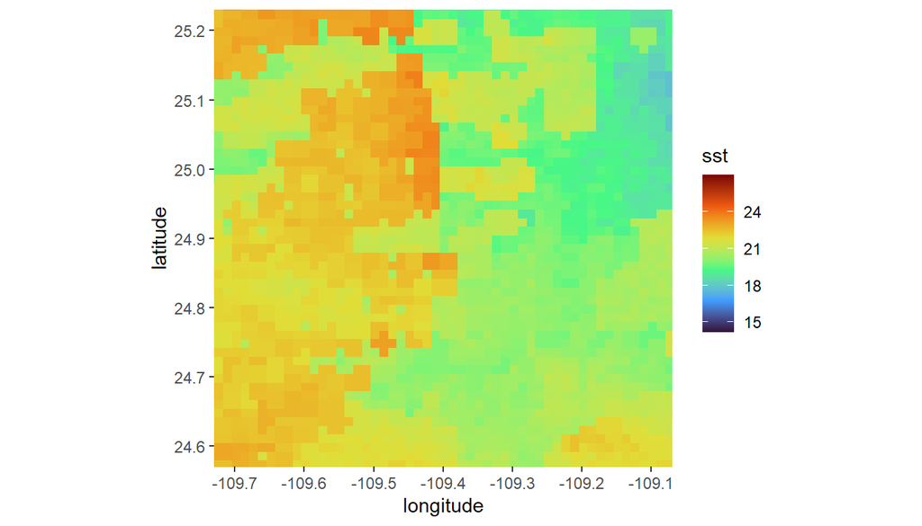

```r
ggplot() +
 geom_raster(data=SST_dfclean,aes(x=longitude, y=latitude, fill = sst))+ scale_fill_viridis_c(option = "H")+
 geom_polygon(data = world_df, aes(x = long, y = lat, group = group), colour = '#403d39', fill = "#e5e5e5") +
 coord_sf(xlim = c(-109.7,-109.1),ylim = c(24.6,25.2))
```

# Create buffer

Load package **sp**.

```r
library(sp)
```

Give coordinates from the central point.

```r
This_point<-data.frame(Longitude=-109.37728617302638,Latitude=24.92572600240793)
```

Use this custom function to create a buffer. Note that it uses epsg 4236, adjust if necessary.

```r
create_buffer<-function(central_point=central_point, buffer_km=buffer_km){
  central_spatial<- sp::SpatialPoints(cbind(central_point$Longitude,central_point$Latitude))
  sp::proj4string(central_spatial)= sp::CRS("+init=epsg:4326")
  central_spatial <- sp::spTransform(central_spatial, sp::CRS("+init=epsg:4326"))
  central_spatial<-sf::st_as_sf(central_spatial)
  buffer_dist<-buffer_km*1000
  central_buffer<-sf::st_buffer(central_spatial, buffer_dist)
  return(central_buffer)
  }
```

The central point and the kilometers are the arguments needed.

```r
This_buffer<-create_buffer(central_point=This_point,buffer_km=20)
```

Confirm that the buffer is not a SpatialPolygons.

```r
class(This_buffer)
```

```
## [1] "sf"         "data.frame"
```

# Map

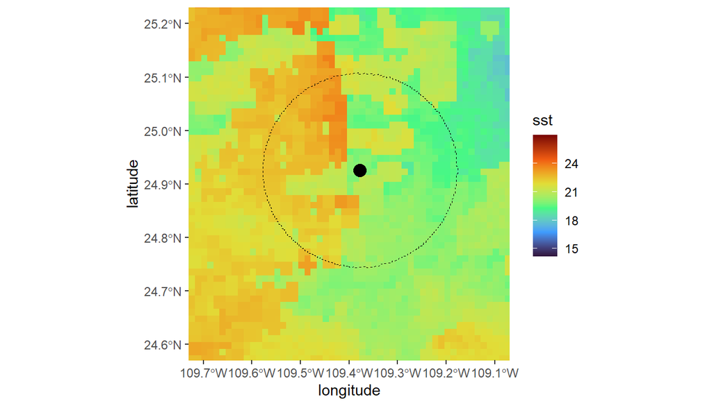

```r
ggplot() +
 geom_raster(data=SST_dfclean,aes(x=longitude, y=latitude, fill = sst))+ scale_fill_viridis_c(option = "H")+
 geom_polygon(data = world_df, aes(x = long, y = lat, group = group), colour = '#403d39', fill = "#e5e5e5") +
 geom_sf(data = This_buffer,
          color = "black",
          fill = NA,  # equivalent to 'transparent'
          linetype = "dashed")+
 geom_point(data=This_point, aes(x=Longitude, y=Latitude), colour = "black", size = 4)+
 coord_sf(xlim = c(-109.7,-109.1),ylim = c(24.6,25.2))
```

# Extract information

Convert the SST data into a SpatialPointsDataFrame.

```r
SST_sp <- SST_dfclean
sp::coordinates(SST_sp) <- ~longitude + latitude
sp::proj4string(SST_sp) = sp::CRS("+init=epsg:4326")
```

```r
SST_sp<-sf::st_as_sf(SST_sp)
```

```r
#LALI01_1colony_over<- over(LALI01_1colony_points,Colony_buffer)
SST_buffer<-sapply(sf::st_intersects(SST_sp,This_buffer), function(z) if (length(z)==0) NA_integer_ else z[1])
```

The SST values that fall inside the buffer are now added as a column named **sst_inside** in the data frame.

```r
SST_dfclean$sst_inside <- as.numeric(SST_buffer)
```

The values that fall inside the buffer are shown as **1**.  
To keep only the data inside the buffer select only those rows with values inside the buffer using the function **filter**.

```r
SST_inside<-SST_dfclean %>%
  filter(sst_inside==1)%>%
  drop_na(sst)
```

# Subset

To plot the SST data, select the information from the new data frame **SST_inside** and the function **geom_raster** to plot the information.

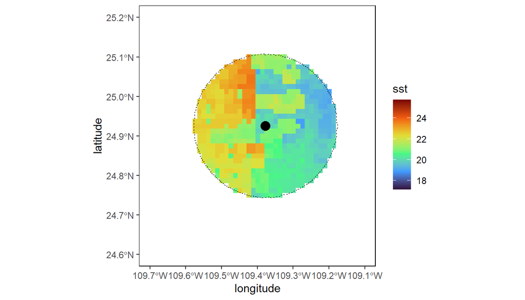

```r
ggplot() +
  geom_raster(data=SST_inside,aes(x=longitude, y=latitude, fill = sst))+ scale_fill_viridis_c(option = "H")+
  geom_polygon(data = world_df, aes(x = long, y = lat, group = group), colour = '#403d39', fill = "#e5e5e5") +

  geom_sf(data = This_buffer,
          color = "black",
          fill = NA,  # equivalent to 'transparent'
          linetype = "dashed")+
  geom_point(data=This_point, aes(x=Longitude, y=Latitude), colour = "black", size = 4)+
  theme(panel.background = element_blank(),
        panel.border = element_rect(colour = "black", fill='transparent'))+
  coord_sf(xlim = c(-109.7,-109.1),ylim = c(24.6,25.2))+
  NULL
```

Use the values inside the buffer to calculate the average SST

```r
mean(SST_inside$sst)
```

```
## [1] 20.61818
```

```r
sd(SST_inside$sst)
```

```
## [1] 1.656545
```